# Answering the Question: In what ways do members and casual riders use Divvy bikes differently?

Chi Kit Yeung

## Guiding questions

- Where is your data located?
- How is the data organized?
- Are there issues with bias or credibility in this data? Does your data ROCCC?
- How are you addressing licensing, privacy, security, and accessibility?
- How did you verify the data’s integrity?
- How does it help you answer your question?
- Are there any problems with the data?

## Setting up the environment

Loading all the necessary packages

## Loading the Data

The data is stored in csv files that are organized monthly.

```r
# Loading the data
path <- "./divvy-tripdata/"
filenames <- list.files(path = path)
```

### Into a list

Since our data is being store in multiple csv files, I’ll be using a loop to store each data frame into a list. Doing so avoids cluttering up local environment.

```r
all_df <- lapply(filenames, function(i) {
  i <- paste(path,i,sep="")
  read.csv(i, header=FALSE)
  })
filenames <- gsub("-","_",filenames)
names(all_df) <- gsub(".csv","",filenames)
```

### Wrangling the Data

```r
joined_df <- all_df %>%
  reduce(full_join)
# Renaming the data frame
## reduce() function renamed the columns with some place holder values and placed the actual names into the first row of the data frame.
names(joined_df) <- joined_df[1,]
df <- joined_df %>%
  slice(-1)
```

#### Let’s see what it’s like

```r
str(df)
```

```
'data.frame':   5860776 obs. of  13 variables:
 $ ride_id           : chr  "99FEC93BA843FB20" "06048DCFC8520CAF" "9598066F68045DF2" "B03C0FE48C412214" ...
 $ rideable_type     : chr  "electric_bike" "electric_bike" "electric_bike" "electric_bike" ...
 $ started_at        : chr  "2021-06-13 14:31:28" "2021-06-04 11:18:02" "2021-06-04 09:49:35" "2021-06-03 19:56:05" ...
 $ ended_at          : chr  "2021-06-13 14:34:11" "2021-06-04 11:24:19" "2021-06-04 09:55:34" "2021-06-03 20:21:55" ...
 $ start_station_name: chr  "" "" "" "" ...
 $ start_station_id  : chr  "" "" "" "" ...
 $ end_station_name  : chr  "" "" "" "" ...
 $ end_station_id    : chr  "" "" "" "" ...
 $ start_lat         : chr  "41.8" "41.79" "41.8" "41.78" ...
 $ start_lng         : chr  "-87.59" "-87.59" "-87.6" "-87.58" ...
 $ end_lat           : chr  "41.8" "41.8" "41.79" "41.8" ...
 $ end_lng           : chr  "-87.6" "-87.6" "-87.59" "-87.6" ...
 $ member_casual     : chr  "member" "member" "member" "member" ...
```

### Cleaning the Data

Looks like all the data is imported as ‘character’ data type. Converting them to the correct types.

```r
## Converting to correct data types, removing entries with NA
df_clean <- df %>%
  mutate(started_at = ymd_hms(started_at)) %>%
  mutate(ended_at = ymd_hms(ended_at)) %>%
  mutate(start_lat = as.double(start_lat)) %>%
  mutate(start_lat = as.double(start_lng)) %>%
  mutate(start_lat = as.double(end_lat)) %>%
  mutate(start_lat = as.double(end_lng)) %>%
  mutate(ride_length = as_hms(difftime(ended_at, started_at)), .after = ended_at) %>%
  remove_empty(which = c("rows", "cols")) %>%
  na.omit() %>%
  filter(started_at<=ended_at) %>% # remove cases where end time is somehow before the start time
  as_tibble()
```

#### Calculating some basic stats

```r
## Getting average amount of time different rider types ride
df_stats <- df_clean %>%
  group_by(member_casual) %>%
  summarise(mean = as.duration(round(mean(ride_length))),
            max = as.duration(round(max(ride_length))),
            min = as.duration(round(min(ride_length))),
            sd = as.duration(round(sd(ride_length))),
            median = as.duration(round(median(ride_length)))
            )

  kable(df_stats)
```

| member_casual | mean | max | min | sd | median |
| --- | --- | --- | --- | --- | --- |
| casual | 1672s (~27.87 minutes) | 3356649s (~5.55 weeks) | 0s | 12788s (~3.55 hours) | 914s (~15.23 minutes) |
| member | 767s (~12.78 minutes) | 89996s (~1.04 days) | 0s | 1187s (~19.78 minutes) | 546s (~9.1 minutes) |

Wow.. the longest ride is *5 weeks*?! There’s definitely some outliers here. Probably someone who took out a bike and forgot to return it (o_o”)

#### Applying some statistics to help filter out the outliers

| member_casual | q2 | q3 | q4 | iqr | lower | min | upper | max |
| --- | --- | --- | --- | --- | --- | --- | --- | --- |
| casual | 520s (~8.67 minutes) | 915s (~15.25 minutes) | 1668s (~27.8 minutes) | 1148s (~19.13 minutes) | -1202s (~-20.03 minutes) | 1s | 3390s (~56.5 minutes) | 3356649s (~5.55 weeks) |
| member | 317s (~5.28 minutes) | 547s (~9.12 minutes) | 948s (~15.8 minutes) | 631s (~10.52 minutes) | -629.5s (~-10.49 minutes) | 1s | 1894.5s (~31.58 minutes) | 89996s (~1.04 days) |

### Noting down some ideas

- Usage trends by month
- Usage trends by time of day
- Difference in ride distance

```r
df_filter <- df_clean %>%
  subset(select = c(ride_id, rideable_type, started_at, ended_at, ride_length, member_casual)) %>%
  filter(as.duration(ride_length)<df_quantile$upper) %>%
  mutate(month = ym(format(as.Date(started_at), "%Y-%m")))
```

| member_casual | mean | max | min | sd | median |
| --- | --- | --- | --- | --- | --- |
| casual | 929s (~15.48 minutes) | 3389s (~56.48 minutes) | 1s | 624s (~10.4 minutes) | 781s (~13.02 minutes) |
| member | 669s (~11.15 minutes) | 3389s (~56.48 minutes) | 1s | 500s (~8.33 minutes) | 528s (~8.8 minutes) |

# Descriptive Analysis

## Ridership by type and weekday

| Type | Weekday | Ride Length |
| --- | --- | --- |
| casual | Sun | 1004.4653 secs |
| member | Sun | 727.8924 secs |
| casual | Mon | 923.1539 secs |
| member | Mon | 650.9789 secs |
| casual | Tue | 864.3906 secs |
| member | Tue | 641.2614 secs |
| casual | Wed | 865.7356 secs |
| member | Wed | 647.6209 secs |
| casual | Thu | 868.0591 secs |
| member | Thu | 648.5437 secs |
| casual | Fri | 902.5364 secs |
| member | Fri | 657.8947 secs |
| casual | Sat | 994.1535 secs |
| member | Sat | 728.4653 secs |

## Visualizing it

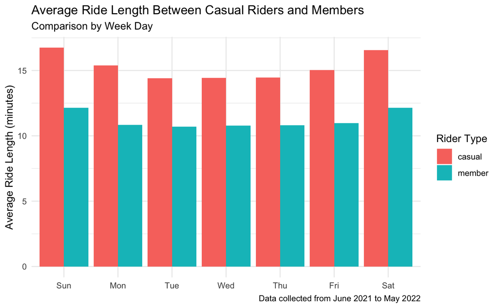

```r
df_ride_weekday %>%
  ggplot(aes(x = weekday)) +
  geom_col(aes(y = average/60, fill = member_casual), position = "dodge") +
  theme_minimal() +
  labs(title = "Average Ride Length Between Casual Riders and Members",
       subtitle = "Comparison by Week Day",
       y = "Average Ride Length (minutes)",
       x = NULL,
       fill = "Rider Type",
       caption = "Data collected from June 2021 to May 2022")
```

Casual riders consistently seem to rent the bikes for longer than members.

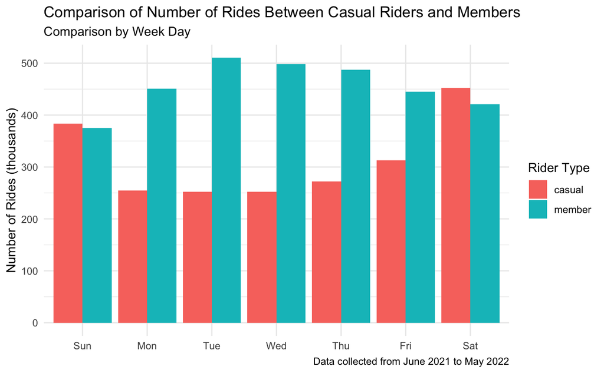

Members ride a lot more on weekdays compared to Casual riders who edge out more rides on weekends.

# Visualizing the number of rides per month

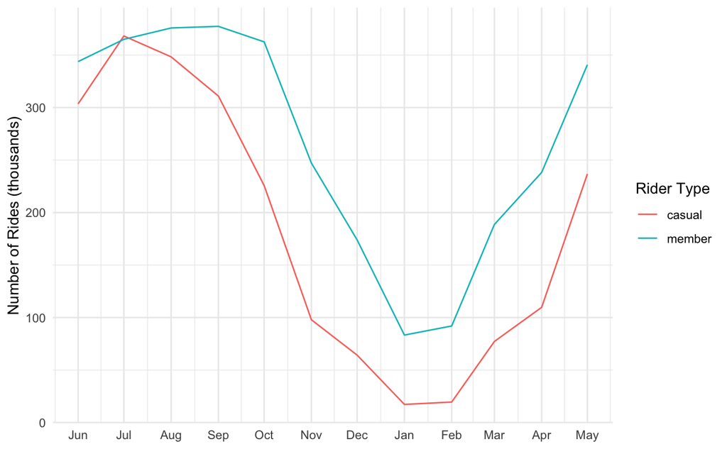

Both types of riders seem to follow the same monthly riding trends. Most riders are not fond of riding during winter months.

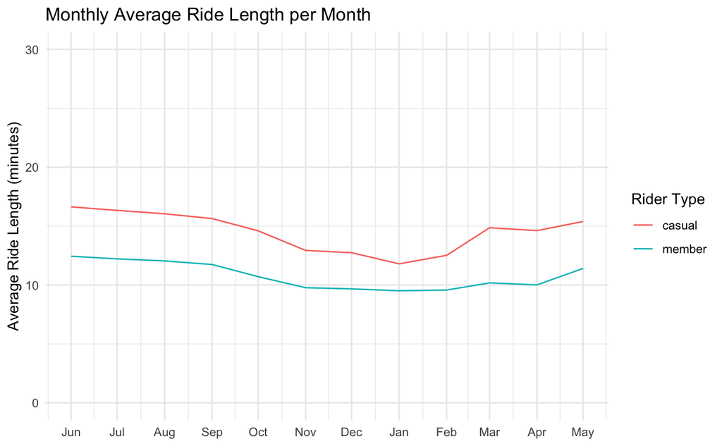

```r
df_filter %>%
  group_by(member_casual, year_month) %>%
  summarise(average_ride = mean(as.numeric(as.duration(ride_length), "minutes"))) %>%
  ggplot() +
  geom_line(aes(x = year_month, y = average_ride, color = member_casual)) +
  theme_minimal() +
  scale_x_date(date_breaks = "1 month", date_labels = "%b") +
  scale_y_continuous(limits = c(0, 30)) +
  labs(title = "Monthly Average Ride Length per Month", x = NULL, y = "Average Ride Length (minutes)", color = "Rider Type")
```

Again we can observe that casual riders tend to spend more time riding compared to members.

# Let’s see bike types

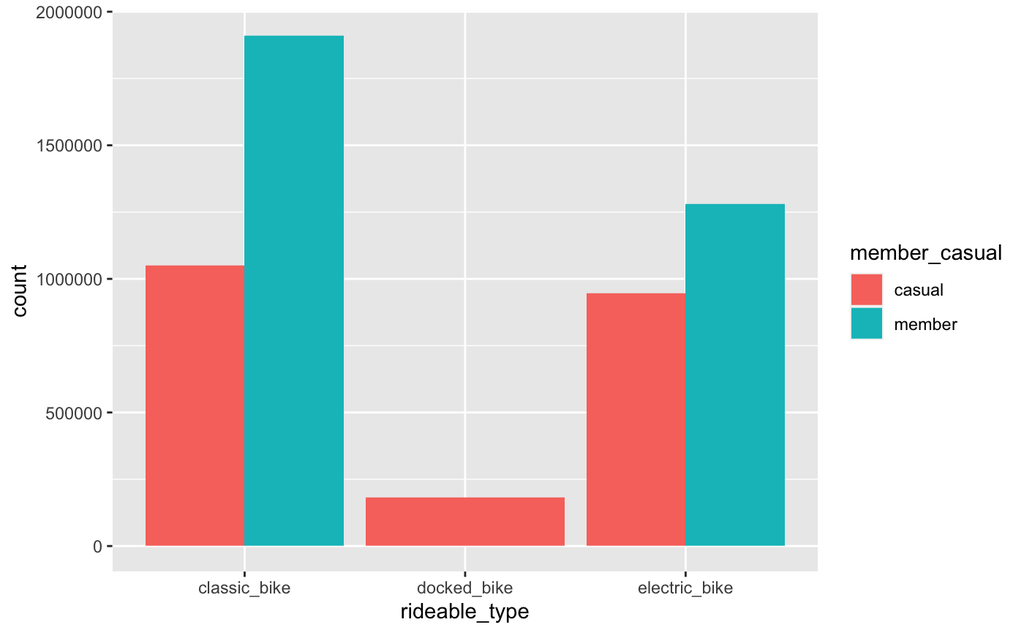

```r
df_filter %>%
  group_by(member_casual, rideable_type) %>%
  summarise(count = n()) %>%
  ggplot(aes(x = rideable_type, y = count, fill = member_casual)) +
  geom_col(position = "dodge")
```